# Programming with R — A Beginners’ Guide for Geoscientists

3 - Statistics

Tobias Stephan

09/02/2022

```r
pacman::p_load(
  # data manipulation
  dplyr,

  # Plotting
  ggplot2
)

# my functions and stuff for the course
source("course_stuff.R")
```

## Descriptive statistics

### One variable (Univariate statistics)

The goal of univariate statistics is to explore the spread (or distribution) of a variable.

**Background**

Types of Variables:

- *Categorical* = qualitative variables
  - *Nominal*: variable has two or more categories, but there is no ordering (*rank*) (e.g. binary variables (0 vs. 1, yes vs. no, true vs. false), blood type (A, B, AB, or O) rock type (magmatic, sedimentary, or metamorphic)).
  - *Ordinal*: similar as categorical, but there is a clear ordering (or rank) of the categories (e.g. economic status low-medium-high, ).
  - *Discrete numerical*: variable can only be a finite number of real values within a given interval (e.g. a score of a judge between 0 and 10).
- *Continuous (numerical)* = quantitative variables (Similar to discrete numerical values, except that the variable can be any an infinite number of real values within a given interval)
  - *Intervals*: ordered units that have the same difference (e. g. temperatures in degrees Celsius or Fahrenheit as difference between 20°C and 30°C is the same as 30°C to 40°C)
  - *Ratios*: same as intervals but with an absolute zero (none of a variable). E.g. temperature in K, distance, weight, age, ….

```r
data <- read_geochron("Data/Geochron_sample_download_UPb.xls")
samples <- data$isotopes %>%
  mutate(st.Pb206U238.perc = st.Pb206U238 / t.Pb206U238)

sample1 <- samples %>% filter(Sample_ID == "Whitehorse Formation")
```

Important values to characterize the distribution of the variable `sample1$st.Pb206U238.perc` are:

```r
# minimum maximum
min(sample1$st.Pb206U238.perc)
```

```
## [1] 0.008135829
```

```r
# maximum
max(sample1$st.Pb206U238.perc)
```

```
## [1] 0.06985111
```

```r
# mean
mean(sample1$st.Pb206U238.perc)
```

```
## [1] 0.01932261
```

```r
# median
median(sample1$st.Pb206U238.perc)
```

```
## [1] 0.01752407
```

```r
# quantiles
quantile(sample1$st.Pb206U238.perc)
```

```
##          0%         25%         50%         75%        100%
## 0.008135829 0.012976014 0.017524072 0.022604296 0.069851111
```

```r
# variance
var(sample1$st.Pb206U238.perc)
```

```
## [1] 9.393132e-05
```

```r
# standard deviation
sd(sample1$st.Pb206U238.perc)
```

```
## [1] 0.009691817
```

**Mathematical background**

- Mean $|X| = \frac{\sum(x_i)}{n}$
- Variance $\sigma_X^2 = \frac{1}{n}\sum(x_i - |X|)^2$
- Standard deviation $\sigma_X = \sqrt{\sigma_X^2}$

$x$ the variable/observation

$n$ is the number of observations (sample size)

#### Visualization of the distibution

##### Boxplot

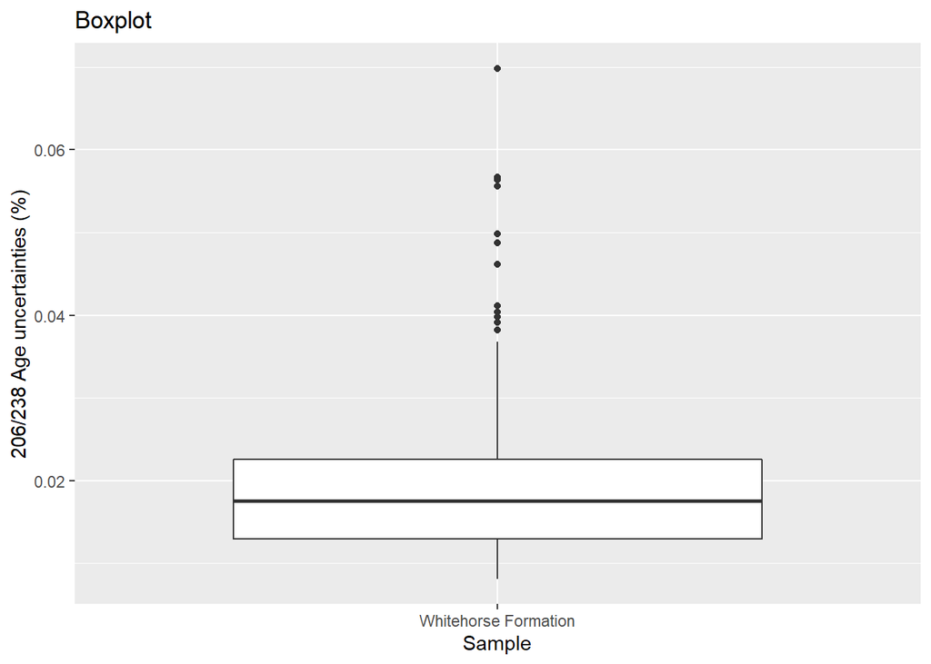

```r
# simple plot
# boxplot(sample1$st.Pb206U238.perc)

# ggplot
ggplot(data = sample1, aes(x = Sample_ID, y = st.Pb206U238.perc)) +
  geom_boxplot() +
  labs(title = "Boxplot", x = "Sample", y = "206/238 Age uncertainties (%)")
```

Btw, if you want to have the boxplot for more than one sample… R automatically identifies when there are more than one sample in your data set.

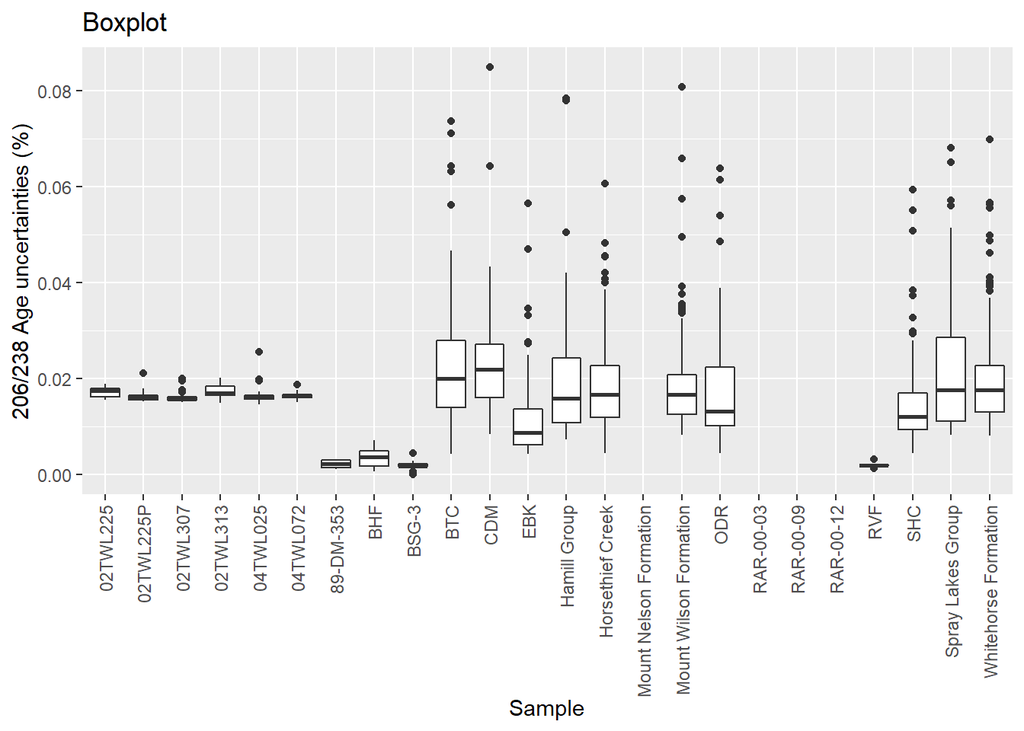

```r
ggplot(data = samples, aes(x = Sample_ID, y = st.Pb206U238.perc)) +
  geom_boxplot() +
  labs(title = "Boxplot", x = "Sample", y = "206/238 Age uncertainties (%)") +
  theme(axis.text.x = element_text(angle = 90, vjust = 0.5, hjust = 1))
```

##### Histogram

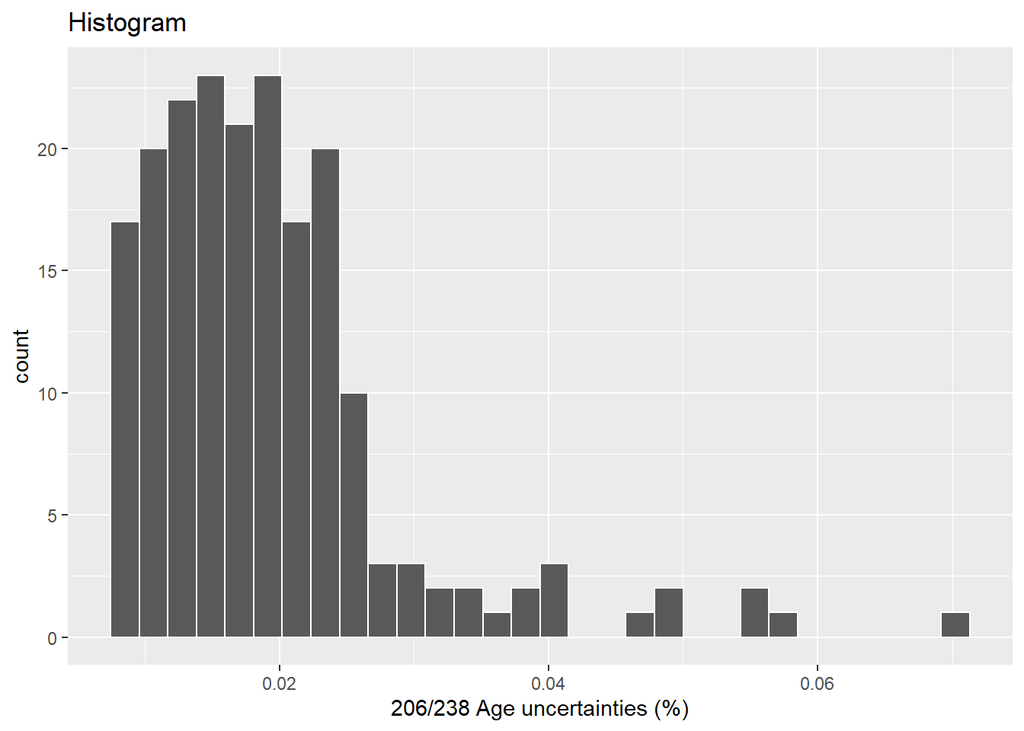

```r
# simple plot
# hist(sample1$st.Pb206U238.perc)

# ggplot
ggplot(data = sample1, aes(x = st.Pb206U238.perc)) +
  geom_histogram(color = "white") + # adds the histogram
  labs(title = "Histogram", x = "206/238 Age uncertainties (%)") # add description
```

**R** finds the optimal width of the bins automatically. You can also give a specific bin width by defining `binwidth` or the number of bins by `bins` as options int in the `geom_histogram()` function. See `?geom_histogram()` for more information

If you want to show more than one sample in one histogram plot and color them according to their sample, just define the `fill` option.

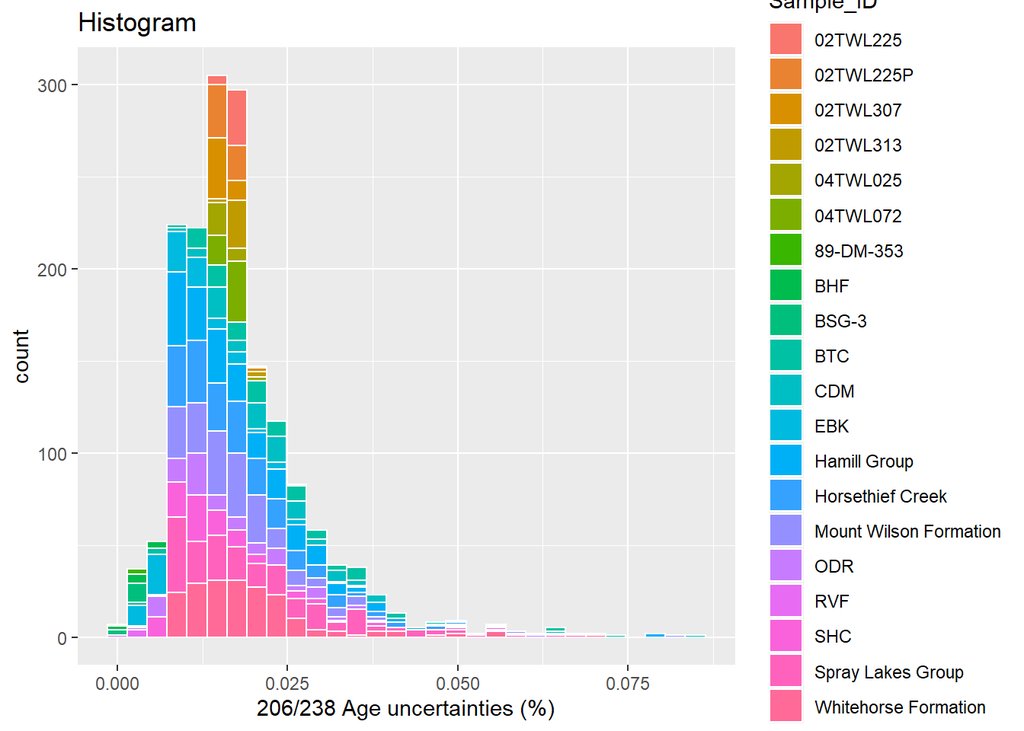

```r
ggplot(data = samples, aes(x = st.Pb206U238.perc, fill = Sample_ID)) +
  geom_histogram(color = "white") + # adds the histogram
  labs(title = "Histogram", x = "206/238 Age uncertainties (%)") # add description
```

#### Statistical tests

How to check the normality? It’s possible to use the **Shapiro-Wilk normality test** and to look at the normality plot.

Shapiro-Wilk test:

- Null hypothesis: the data are normally distributed
- Alternative hypothesis: the data are not normally distributed

```r
shapiro.test(sample1$st.Pb206U238.perc)
```

```
##
##  Shapiro-Wilk normality test
##
## data:  sample1$st.Pb206U238.perc
## W = 0.80824, p-value = 8.734e-15
```

From the output, the p-value is less than the significance level 0.05 implying that the distribution of the data is significantly different from a normal distribution.

Visual inspection of the data normality using **Q-Q plots** (quantile-quantile plots). Q-Q plot draws the correlation between a given sample and the normal distribution.

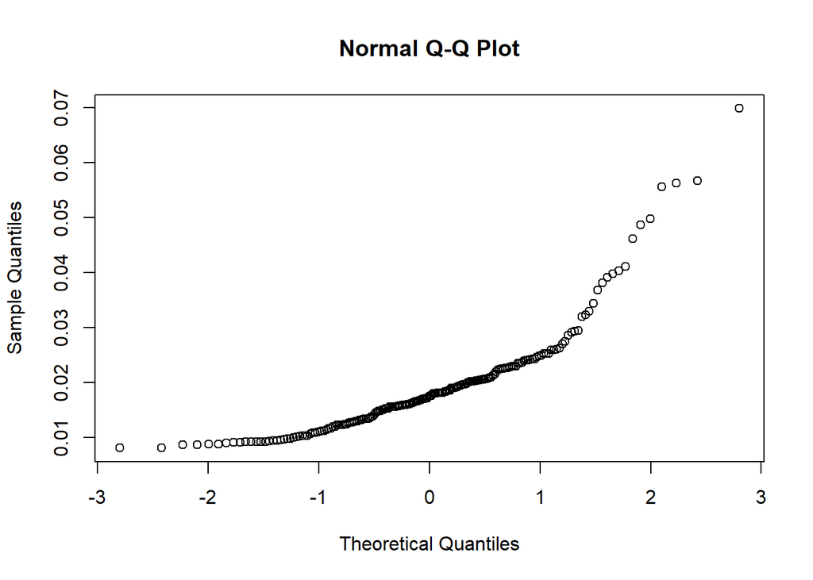

```r
# simple R plot
qqnorm(sample1$st.Pb206U238.perc)
```

From the normality plots, we conclude that the data does not come from normal distributions.

Does the mean has any value for the variable?

- Normally distributed values: One Sample t-test `t.texst()`
- Non normally distributed values: Non parametric one-sample Wilcoxon rank test `wilcox.test()`

```r
# t.test(sample1$st.Pb206U238.perc)
wilcox.test(sample1$st.Pb206U238.perc)
```

```
##
##  Wilcoxon signed rank test with continuity correction
##
## data:  sample1$st.Pb206U238.perc
## V = 19306, p-value < 2.2e-16
## alternative hypothesis: true location is not equal to 0
```

The **p-value** of the test is 2.2x10<sup>-16</sup>, which is less than the significance level alpha = 0.05. We can conclude that the mean uncertainties of the reported uncertainties is significantly different from 0 with a **p-value** = 2.2x10<sup>-16</sup>.

### Two variables (Bivariate statistics)

The goal of bivariate statistics is to explore how two different variables relate to or differ from each other.

Values:

**Mathematical background**

- Covariance $\sigma_{XY} = \frac{1}{n} \sum(x_i - |X|)(y_i - |Y|)$
- Correlation $R_{XY} = \frac{\sigma_{XY}}{\sigma_X \sigma_Y}$

```r
# covariance
# cov(sample1$Age_206.238, sample1$Age_206.238) identical to var() with two input variables
var(sample1$st.Pb206U238, sample1$st.Pb207U235)
```

```
## [1] 75.68803
```

```r
# correlation
cor(sample1$st.Pb206U238, sample1$st.Pb207U235, method = "pearson") # (Pearson) correlation
```

```
## [1] 0.6424031
```

**Background**

The *Pearson correlation (R)* (`method = 'pearson'`) measures a linear dependence between two variables. It’s also known as a **parametric correlation** test because it depends to the distribution of the data: it can be used only when x and y are from *normal distribution*!

If both variables do not come from a bivariate normal distribution, you have to use rank-based correlation coefficients (**non-parametric**), such as the *Kendall rank correlation* (`method = 'kendall'`) or the *Spearman’s rho statistic* (`method = 'spearman'`).

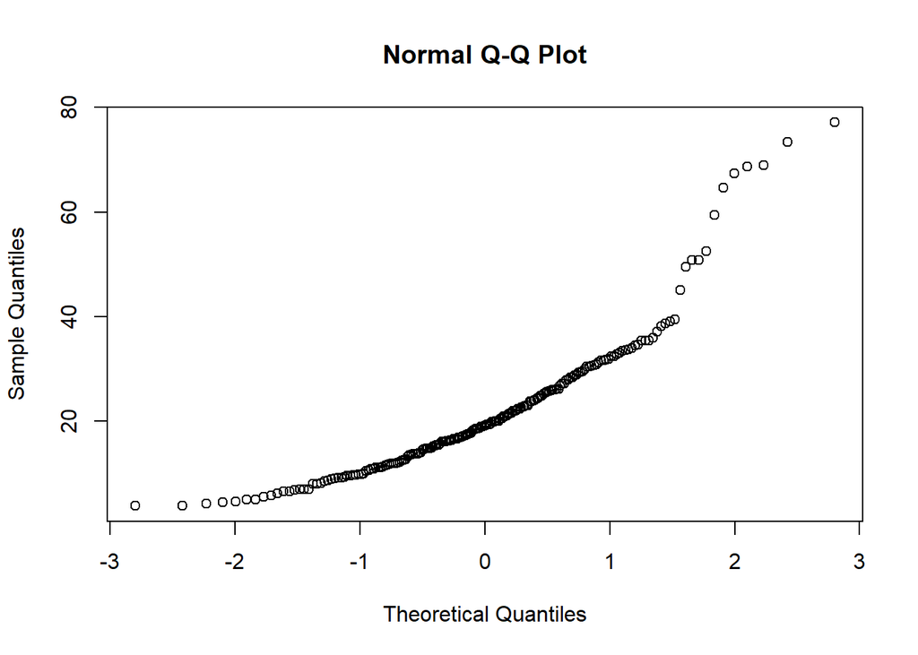

```r
qqnorm(sample1$st.Pb206U238)
```

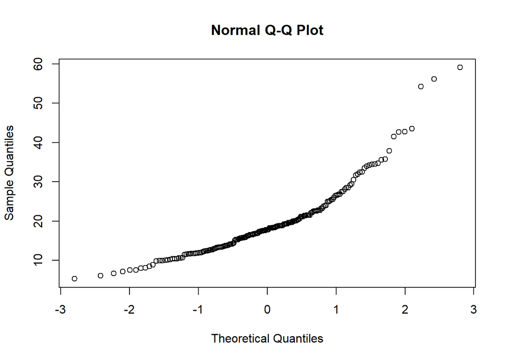

```r
qqnorm(sample1$st.Pb207U235)
```

#### Correlation test

Testing the statistical significance of the correlation:

```r
cor.test(sample1$st.Pb206U238, sample1$st.Pb207U235, method = "pearson")
```

```
##
##  Pearson's product-moment correlation
##
## data:  sample1$st.Pb206U238 and sample1$st.Pb207U235
## t = 11.675, df = 194, p-value < 2.2e-16
## alternative hypothesis: true correlation is not equal to 0
## 95 percent confidence interval:
##  0.5519445 0.7179183
## sample estimates:
##       cor
## 0.6424031
```

In the result above :

- `t` is the t-test statistic value (t = 11.675),
- `df` is the degrees of freedom (df = 194),
- `p-value` is the significance level of the t-test (p-value < 2.2e-16).
- `conf.int` is the confidence interval of the correlation coefficient at 95% (conf.int = [0.5519445, 0.7179183]);
- `sample estimates` is the correlation coefficient (cor = 0.6424031).

The p-value of the test is <2.2x10<sup>-16</sup>, which is less than the significance level alpha = 0.05. We can conclude that the two variables are significantly correlated with a correlation coefficient of 0.64 and p-value of <2.2x10<sup>-16</sup>.

#### Visualization of the correlation

##### Linear Regression

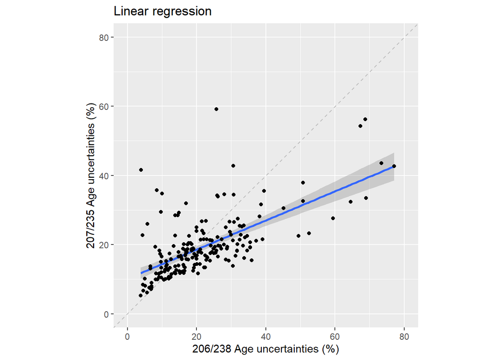

```r
# simple R plot
# plot(sample1$st.Pb206U238, sample1$st.Pb207U235)

ggplot(data = sample1, aes(st.Pb206U238, st.Pb207U235)) +
  coord_fixed(xlim = c(0, 80), ylim = c(0, 80)) + # x and y axis have same scaling
  geom_abline(slope = 1, lty = 2, color = "grey") + # drwas a diagonal line with slope = 1
  geom_smooth(method = "lm", formula = "y~x") + # 'lm' : linear regression
  geom_point() + # adds points
  labs(
    title = "Linear regression",
    x = "206/238 Age uncertainties (%)",
    y = "207/235 Age uncertainties (%)") # add description
```

A summary of the linear regression , incl. $R^2$ (goodness-of-fit), can be shown via:

```r
lm_fit <- lm(data = sample1, st.Pb206U238 ~ st.Pb207U235)
summary(lm_fit)
```

```
##
## Call:
## lm(formula = st.Pb206U238 ~ st.Pb207U235, data = sample1)
##
## Residuals:
##     Min      1Q  Median      3Q     Max
## -39.727  -4.842  -0.877   4.732  33.267
##
## Coefficients:
##              Estimate Std. Error t value Pr(>|t|)
## (Intercept)    2.8962     1.7862   1.621    0.107
## st.Pb207U235   0.9808     0.0840  11.675   <2e-16 ***
## ---
## Signif. codes:  0 '***' 0.001 '**' 0.01 '*' 0.05 '.' 0.1 ' ' 1
##
## Residual standard error: 10.3 on 194 degrees of freedom
## Multiple R-squared:  0.4127, Adjusted R-squared:  0.4097
## F-statistic: 136.3 on 1 and 194 DF,  p-value: < 2.2e-16
```

- $R$: The correlation between the observed values of the response variable and the predicted values of the response variable made by the model.
- $R^2$: The proportion of the variance in the response variable that can be explained by the predictor variables in the regression model.

Ideally, when you plot the residuals, they should look random. Otherwise means that maybe there is a hidden pattern that the linear model is not considering. To plot the residuals, use the command `plot(lm_fit$residuals)`.

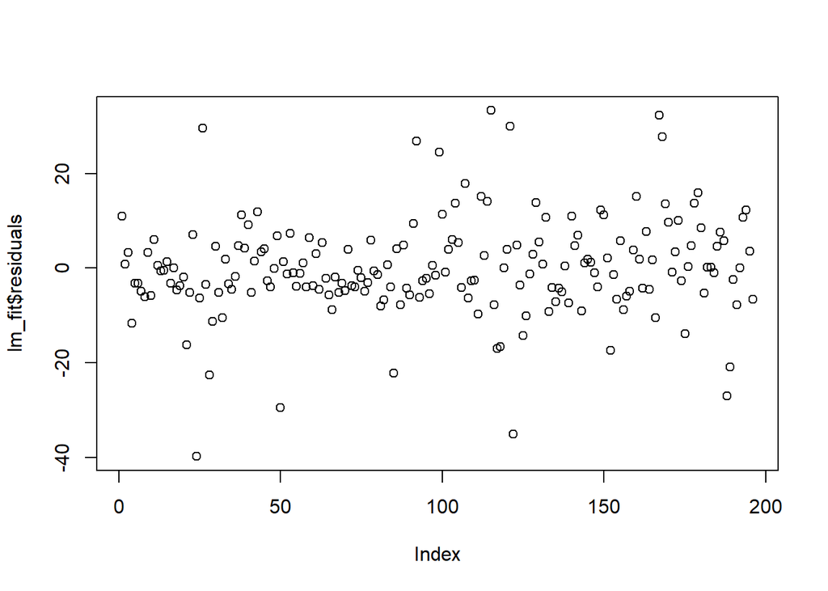

```r
# simple plot
plot(lm_fit$residuals)
```

## Useful resources

- **RECOMMENDED**: Hadley Wickham (the master developer of R) briefly demonstrates data analysis with R in a 22 min youtube video: https://www.youtube.com/watch?v=go5Au01Jrvs&t=10s
- Linear Regression: https://www.datacamp.com/community/tutorials/linear-regression-R
- Correlation tests: http://www.sthda.com/english/wiki/correlation-test-between-two-variables-in-r
- http://r-statistics.co/Statistical-Tests-in-R.html
- [Tolosana-Delgado & Mueller (2021): “Geostatistics for Compositional Data with R”, Springer, Cham](https://link.springer.com/book/10.1007/978-3-030-82568-3)
- [P. Vermeesch: Lecture notes to “Statistics for geoscientists”](https://github.com/pvermees/geostats/blob/main/latex/geostats.pdf)
- [Customizing ggplot Graphs](https://rkabacoff.github.io/datavis/Customizing.html): Graph defaults are fine for quick data exploration, but when you want to publish your results to a blog, paper, article or poster, you’ll probably want to customize the results. Customization can improve the clarity and attractiveness of a graph

## Appendix

- **One Sample t-Test**: a parametric test used to test if the mean of a sample from a normal distribution could reasonably be a specific value. `t.test()`
- **Wilcoxon Signed Rank Test**: To test the mean of a sample when normal distribution is not assumed. Wilcoxon signed rank test can be an alternative to t-Test, especially when the data sample is not assumed to follow a normal distribution. It is a non-parametric method used to test if an estimate is different from its true value. `wilcox.test()`
- **Two Sample t-Test and Wilcoxon Rank Sum Test**: Both t.Test and Wilcoxon rank test can be used to compare the mean of 2 samples. The difference is t-Test assumes the samples being tests is drawn from a normal distribution, while, Wilcoxon’s rank sum test does not.
- **Shapiro Test**: To test if a sample follows a normal distribution. `shapiro.test(numericVector) # Does myVec follow a normal disbn?`
- The **Kolmogorov–Smirnov test** is used to check whether 2 samples follow the same distribution. `ks.test(x, y) # x and y are two numeric vector`
- **Fisher’s F-Test** can be used to check if two samples have same variance. `var.test(x, y) # Do x and y have the same variance?`
- **Chi Squared Test** can be used to test if two categorical variables are dependent, by means of a contingency table `chisq.test()`
- **Correlation**: To test the linear relationship of two continuous variables `cor.test(x, y)`
- The **Kruskal-Wallis Rank Sum Test** (also Kruskal–Wallis H test, or one-way ANOVA on ranks) is a non-parametric method for testing whether samples originate from the same distribution. It is used for comparing two or more independent samples of equal or different sample sizes. `kruskal.test(x)`
- More Commonly Used Tests `fisher.test(contingencyMatrix, alternative = "greater") # Fisher's exact test to test independence of rows and columns in contingency table` `friedman.test() # Friedman's rank sum non-parametric test`

There are more useful tests available in various other packages.

The package `lawstat` has a good collection. The `outliers` package has a number of test for testing for presence of outliers.

Content | previous course: Data | next course: Geochronology